# Omitted variables in Logistic regression

@Hiro_macchan

Friday, January 16, 2015

### はじめに

@a_bicky さんから指摘された内容について、僕が考えていたことと僕が間違えていたことと、僕が調べたことをメモとして記載する。

### 僕が間違えたやりとりはこちら。

> 以前、某勉強会で「ロジスティック回帰は特徴量が独立である必要があり…」「そんな条件ありましたっけ？」って質問したことがあったけど、各特徴量の影響とかも考察したい場合は独立（というか互いに相関が低い）じゃないといけないのかなぁと

> — Takeshi Arabiki (@a_bicky) [2015, 1月 13](https://twitter.com/a_bicky/status/555089745840058368)

> [@a_bicky](https://twitter.com/a_bicky) 関連が強すぎるとマルチコ起こしますけど、そうでない限りには問題ないはずですね。と言うより、各変数間が完全独立なら多変量回帰する必要もない気がしますが…(ｰｰ;)

> — 冥途の旅の一里塚2015 (@Hiro_macchan) [2015, 1月 14](https://twitter.com/Hiro_macchan/status/555162392892420096)

> [@Hiro_macchan](https://twitter.com/Hiro_macchan) はい、関連強くなければ大丈夫って話です。完全独立だと意味ないとはどういうことですか？

> — Takeshi Arabiki (@a_bicky) [2015, 1月 14](https://twitter.com/a_bicky/status/555348665988947968)

> [@a_bicky](https://twitter.com/a_bicky) 例えば、X1 のOutcome への影響を知りたいときにX1 とは完全に独立でOutcome に関連するX2 はモデルに含まなくてもX1 の係数は変わらず結論に影響しないということを言おうと思ったのですが、予測モデルとして使う場合には話が全く異なりますね。。。

> — 冥途の旅の一里塚2015 (@Hiro_macchan) [2015, 1月 14](https://twitter.com/Hiro_macchan/status/555349640065736704)

> [@Hiro_macchan](https://twitter.com/Hiro_macchan) ん？相関 0 の 2 つの説明変数だったとしても片方を除くと係数は変わる気がしますが。1 変数の時も 2 変数の時も尤度関数が最大になるように学習するのに係数は全く同じになって予測精度には影響するってどういうことですか？

> — Takeshi Arabiki (@a_bicky) [2015, 1月 15](https://twitter.com/a_bicky/status/555754337196969984)

> [@a_bicky](https://twitter.com/a_bicky) 二つの因子が独立してoutcomeに関連している場合、たとえ一つの因子を除いてoutcomeへの効果を推計しても推計される効果の大きさはbiasされてないので、漸近的には同じ結果になるかなーと思ったんですが同一集団で推計やれば係数は変わりますよね。失礼しました。

> — 冥途の旅の一里塚2015 (@Hiro_macchan) [2015, 1月 15](https://twitter.com/Hiro_macchan/status/555869395763744769)

> [@a_bicky](https://twitter.com/a_bicky) すいません、考え違えをしていて先の発言は正しくないです。後でまとめて資料をUPします。

> — 冥途の旅の一里塚2015 (@Hiro_macchan) [2015, 1月 16](https://twitter.com/Hiro_macchan/status/555974084127760384)

### 僕がこのやりとりで考えていた事

複数の変数(treat, x1,x2)がy(outcome)と関連しているとする。  
自分がoutcomeとの因果効果を知りたいのは複数の変数の内treatのみであるとする。  
x1,x2 のうちx1 はTreatment と関連しており、x2はTreatment に対して独立している。  
outcomeとtreatmentの関連を推計したいときに調整すべき変数は何か？

疫学系の人だとここでDAGを頭に浮かべるだろう。今回の状況をDAGに表すと、[以下のリンク通り](http://dagitty.net/dags.html?id=g7mzV) である。  
Treat とOutcome の間にバイアスパス（赤色のライン）が存在するのがわかる。  
x1 をブロックすれば(x1のノードを選択してaをタイプすればブロックした事になる)、バイアスパスは消えるためTreat のOutcome に対する効果を正しく推計出来る事になる。

よって、僕は「相関 0 の 2 つの説明変数の片方を除くいても係数は変わらない。」と考えた。

### 問題点

しかし、この考えは誤っていた。  
**outcomeが連続変数で回帰を一般線形回帰で回帰する場合は正しい**が、**outcomeがカテゴリカル変数でlogistic modelを用いて一般的なodds ratio を報告する場合は正しくはない**。  
以下に具体例とその理由、対処を示す。

### シミュレーション

**パラメーターセッティング**  
treat,x2,x3のy(Outcome)に対する効果を推計する。  
いずれの変数もyと関連しておりそれぞれの係数は、beta1,beta2,beta3である。  
treatとx2は相関しており、相関係数はbeta1_beta2である。  
treatとx3は独立している。

**モデル**  
モデルは以下のmodel1~model4 を用いた。

- model1: $y=\beta_1 terat + \beta_2 x_2 + \beta_3 x_3$  
  これは、データ生成過程を全てモデルに投入したモデルで正しい推計がなされている。
- model2: $y=\beta_1 terat$  
  これは、Treat のみをモデルに投入したモデル。
- model3: $y=\beta_1 treat + \beta_3 x3$  
  これは、Treat model1 からTreat に関連している$x_2$ を取り除いたモデル。  
  DAGでいうバイアスパスが開いた状態
- model4: $y=\beta_1 treat + \beta_2 x2$  
  これは、Treat model1 からTreat に無関係な$x_3$ を取り除いたモデル。  
  DAGでいうx3を補正した状態

#### 一般線形回帰で係数を報告する。

連続量のアウトカムを上記計数から設定し、100回ほど乱数を生成した。  
一般線形モデルで回帰した結果をストックし、1-4のモデルにおけるtreatの係数を箱ひげ図にて示した。

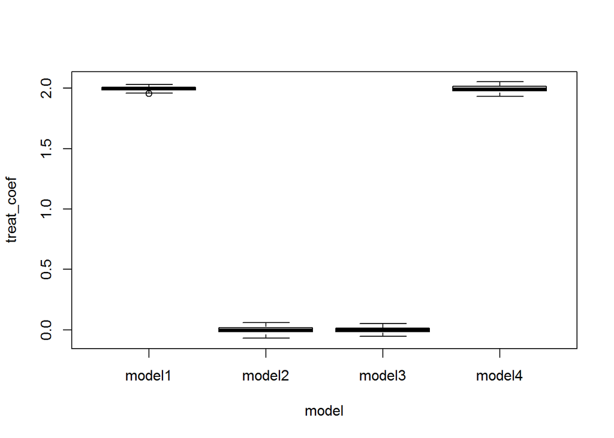

```r
boot <- 100
beta1 <- 2
beta2 <- -2
beta3 <- 1.5
beta1_beta2 <- 1
res_mat <- matrix(,boot,4)
res_mat_2 <- matrix(,boot,2)
res_mat_3 <- matrix(,boot,3)
res_mat_4 <- matrix(,boot,3)

for(i in 1:boot){
  n <- 10000
  x1 <- rnorm(n,mean = 0,sd=10)
  e2 <- rnorm(n,mean = 0,sd=10)
  x2 <- beta1_beta2*x1 + e2
  x3 <- rnorm(n,mean = 0,sd=10)
  e <- rnorm(n,mean = 0,sd=10)
  y <- beta1*x1+beta2*x2+ beta3*x3 +e

  res <- lm(y~x1+x2+x3)
  res_mat[i,] <- res$coefficients

  res_2 <- lm(y~x1)
  res_mat_2[i,] <- res_2$coefficients


  res_3 <- lm(y~x1+x3)
  res_mat_3[i,] <- res_3$coefficients

  res_4 <- lm(y~x1+x2)
  res_mat_4[i,] <- res_4$coefficients

}
treat_coef <- cbind(res_mat[,2],res_mat_2[,2],res_mat_3[,2],res_mat_4[,2])
colnames(treat_coef) <- c("model1","model2","model3","model4")
boxplot(treat_coef, xlab = "model", ylab = "treat_coef")
```

#### 一般化線形回帰（ロジスティックモデル）でOdds ratioを報告する。

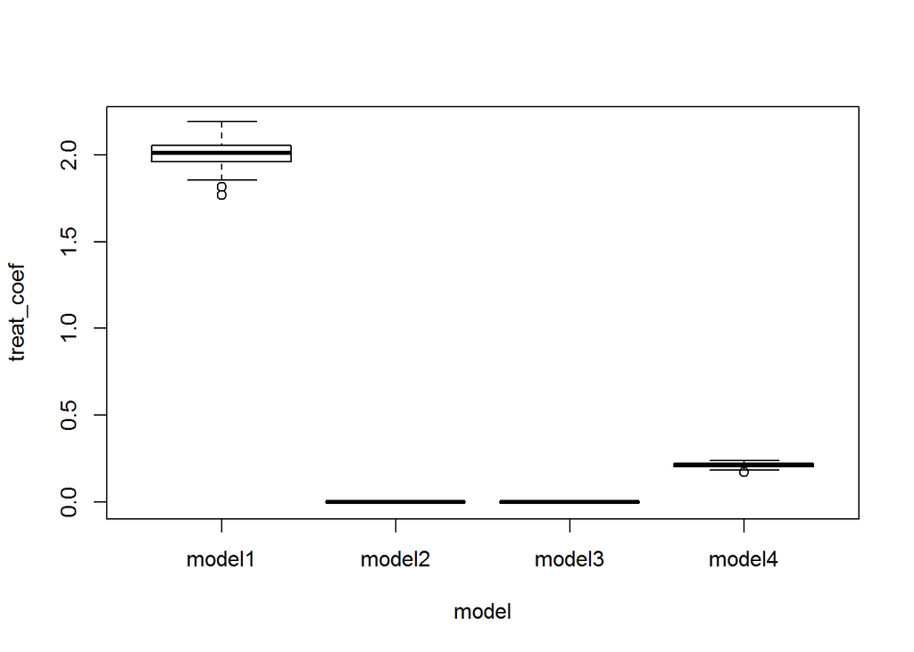

```r
boot <- 100
beta1 <- 2
beta2 <- -2
beta3 <- 1.5
beta1_beta2 <- 1
res_mat <- matrix(,boot,4)
res_mat_2 <- matrix(,boot,2)
res_mat_3 <- matrix(,boot,3)
res_mat_4 <- matrix(,boot,3)
mf_mat <- matrix(,boot,4)
mf_mat_2 <- matrix(,boot,2)
mf_mat_3 <- matrix(,boot,3)
mf_mat_4 <- matrix(,boot,3)

for(i in 1:boot){
  n <- 10000
  x1 <- rnorm(n,mean = 0,sd=10)
  e2 <- rlogis(n,0,1)
  x2 <- beta1_beta2*x1 + e2
  x3 <- rnorm(n,mean = 0,sd=10)
  e <- rlogis(n,0,1)
  z <- beta1*x1+beta2*x2+ beta3*x3 +e
  y_pred <- 1/(1+exp(-z))
  y <- ifelse(y_pred<0.5,0,1)

  res <- glm(y~x1+x2+x3, family = binomial(logit))
  res_mat[i,] <- res$coefficients
  mf_mat[i,] <- coef(res) * mean((dlogis(predict(res,type = "link"))))

  res_2 <- glm(y~x1, family = binomial(logit))
  res_mat_2[i,] <- res_2$coefficients
  mf_mat_2[i,] <- coef(res_2) * mean((dlogis(predict(res_2,type = "link"))))

  res_3 <- glm(y~x1+x3, family = binomial(logit))
  res_mat_3[i,] <- res_3$coefficients
  mf_mat_3[i,] <- coef(res_3) * mean((dlogis(predict(res_3,type = "link"))))


  res_4 <- glm(y~x1+x2, family = binomial(logit))
  res_mat_4[i,] <- res_4$coefficients
  mf_mat_4[i,] <- coef(res_4) * mean((dlogis(predict(res_4,type = "link"))))
}
treat_coef <- cbind(res_mat[,2],res_mat_2[,2],res_mat_3[,2],res_mat_4[,2])
colnames(treat_coef) <- c("model1","model2","model3","model4")
boxplot(treat_coef, xlab = "model", ylab = "treat_coef")
```

ご覧の通り、model1以外全てのモデルがbiasされている。

### 対応

では、この事態をどう回避すればよいのか？  
*Average Partial Effect(APE)* を推計すれば回避できる。  
APE とはロジスティックモデルの結果を利用した仮想的なRisk Differnce にあたる。  
2値変数x のAPEを求める場合、すべての症例がx=1 であった場合の推計イベント割合から、すべての症例がx=0 であった場合の推計イベント割合を引いて算出される。  
具体的には以下の式による[2]。

$g(z) = \frac{1}{1+exp(-z)}$

$APE = N^{-1}\sum_{i=1}^{N}{[g(\hat{\beta_1}+\hat{\beta_2}x_{i2}+\cdots+\hat{\beta_{K-1}}x_{i,K-1}+\hat{\beta_{K}})-g(\hat{\beta_1}+\hat{\beta_2}x_{i2}+\cdots+\hat{\beta_{K-1}}x_{i,K-1})]} \cdots x_K がbinary$

先ほどの推計からAPEを推計した結果を下記に示す。

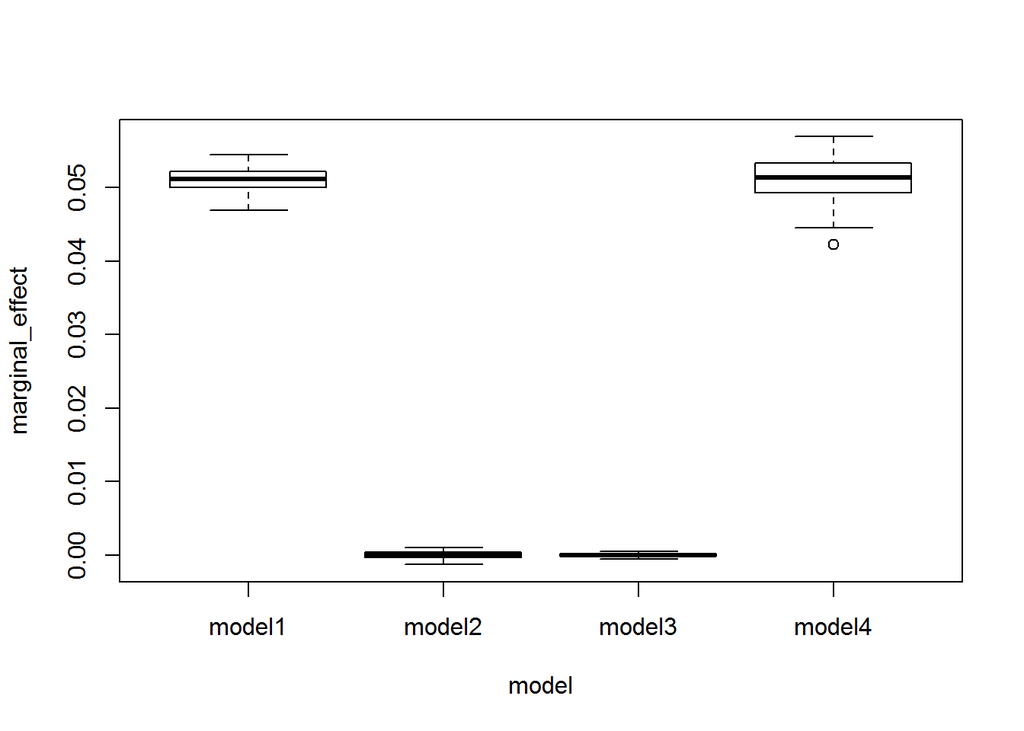

ご覧の通り、モデル1とモデル4の結果が合致している。 結果に大きく影響しTreatと独立した変数が無視されている場合、APEを報告した方が何かと無難っぽい。  
ちなみに、Treat に関連した変数が無視しされた場合は内生性の問題になるので対応は別問題になる。  
今まであんまり意識してなかったなぁ。あと、各種Reporting Guideもodds ratioの報告を推奨しているけどどうなんこれ？

### 参考資料

[1] Angrist JD, Pischke J-S. Mostly harmless econometrics : an empiricists companion. Cram101; 2013. Section 3.2.2.  
[2] Wooldridge JM. Econometric analysis of cross section and panel data. 2nd ed. MIT Press; 2010. Section 15.7.